# practica_ml

## Practica programacion orientada a objetos

#### Jose Peiro Cardona

En mi caso he seleccionado los modelos de scikit-learn necesarios para realizar un estandarizado de los datos, un PCA a modo de reducción de la dimensionalidad, y varios algoritmos de aprendizaje supervisado para clasificación.

He creado una clase con métodos para preprocesado de los datos, selección de modelos, entrenamiento, test y representaciones gráficas de resultados (curva de ROC)

```python
import numpy as np
import pandas as pd
from itertools import cycle

from sklearn.preprocessing import StandardScaler
from sklearn.model_selection import train_test_split
from sklearn.decomposition import PCA
from sklearn.ensemble import RandomForestClassifier
from sklearn.tree import DecisionTreeClassifier
from sklearn.metrics import roc_curve, auc
from sklearn.metrics import roc_auc_score

from matplotlib import pyplot as plt
```

```python
from sklearn.model_selection import train_test_split
from sklearn.preprocessing import StandardScaler
from sklearn.decomposition import PCA
from sklearn.ensemble import RandomForestClassifier
from sklearn.metrics import roc_curve, auc
from itertools import cycle
import matplotlib.pyplot as plt
import pandas as pd
import numpy as np

class Pipeline:

    def __init__(self):
        # Constructor por defecto:
        # En este caso sólo se crea el objeto Pipeline vacío, los parámetros y modelos se eligen
        # después (si no se quieren usar los de por defecto)
        pass



    def __preprocess(self, data, test_size=0.3, target='Survived', random_state=42):
        # Método privado para prepocesar los datos.
        # En este caso no es general, es únicamente para el dataset que he seleccionado, aunque podría
        # hacerse más general.
        #
        # target:      parámetro con el nombre de la variable objetivo.
        #
        # datos:       dataset con los datos. En este caso eliminamos filas con NaN y convertimos la variable 'Survived'
        #              en una variable categórica.
        #
        # train, test: datasets de entrenamiento y test respectivamente. Podemos seleccionar el tamaño con 'test_size'
        #              y la semilla del generador aleatorio para que la partición sea siempre la misma.
        #
        # scaler:      el estandarizado de las variables, en este caso un 'StandardScaler' normal para centrar por la media y
        #              dividir por la desviación estándar.

        self.target = target
        data = data.dropna()  # Eliminar filas con NaN
        data[self.target] = data[self.target].astype('category')

        self.train, self.test = train_test_split(data, test_size=test_size, random_state=random_state)
        self.scaler = StandardScaler() #normalizamos



    def __train_scaler(self):

        #ANTIGUO
        #self.scaler.fit(self.train.drop(columns=self.target)) #entrenamos la variables no objetivo

        # Método privado para entrenar el Scaler.
        numeric_columns = self.train.select_dtypes(include=np.number).columns
        self.scaler.fit(self.train[numeric_columns])



    def scaler_transform(self, data=pd.DataFrame(None)):
        # Método público para transformar los datos para escalarlos.
        # Si no le pasamos datos transforma los datos que hemos seleccionado para entrenamiento y
        # los almacena en el parámetro 'scaled_predictors', sin embargo, si pasamos un dataset
        # nos transformará los datos que le pasemos y los devolverá.

        if not data.empty:
            return self.scaler.transform(data)
        else:
            self.scaled_predictors = self.scaler.transform(self.train.drop(columns=self.target))



    def reduccion(self, model, **kwargs):
        # Método público para guardar en el parámetro 'red_model' el modelo que queramos usar para
        # reducción de la dimensionalidad.
        # Podemos pasar también los argumentos necesarios para el algoritmo que hayamos seleccionado.

        self.red_model = model(**kwargs)



    def __train_reduccion(self):
        # Método privado para entrenar el algoritmo de reducción de la dimensionalidad con los datos escalados.

        self.red_model.fit(self.scaled_predictors)



    def reduccion_transform(self, data=pd.DataFrame(None)):
        # Método público para transformar los datos con el algoritmo de reducción de la dimensionalidad.
        # Si no le pasamos datos transforma los datos que hemos seleccionado para entrenamiento y
        # los almacena en el parámetro 'new_space', sin embargo, si pasamos un dataset
        # nos transformará los datos que le pasemos y los devolverá.

        if not data.empty:
            return self.red_model.transform(data)
        else:
            self.new_space = self.red_model.transform(self.scaled_predictors)



    def summary_reduccion(self):
        # Método público para presentar los resultados de la reducción de la dimensionalidad (en este caso PCA)

        plt.figure(figsize=(5, 5))

        plt.bar(range(1, 1 + self.red_model.explained_variance_ratio_.shape[0]), self.red_model.explained_variance_ratio_)
        plt.grid()
        plt.ylim((0, 1))
        plt.xlabel('Componentes')
        plt.ylabel('% varianza explicada')
        plt.title('Proporción de varianza explicada por componente')
        plt.show()



    def preparacion_datos(self, data, **kwargs):
        # Método público para preparar los datos realizando todo el preprocesado.
        # Podemos pasar los distintos argumentos para modificar los valores por defecto.
        #
        # test_size:     tamaño del conjunto de test.
        #
        # target:        nombre de la variable objetivo.
        #
        # random_state:  semilla para el generador de números aleatorios.
        #
        # model:         modelo de reducción de la dimensionalidad, por defecto PCA.
        #
        # n_components:  número de componentes principales para la PCA.
        #
        # Se actualizan todos los parámetros (si los pasamos para modificarlos) y se llama a todos
        # los métodos necesarios para dividir los datos en los conjuntos de entrenamiento y test,
        # entrenar el scaler, transformar los datos, entrenar el PCA y transformar los datos al nuevo
        # espacio obtenido con el PCA.

        test_size = 0.3
        target = 'Survived'
        random_state = 42
        model = PCA
        n_components = 2
        for arg in kwargs.keys():
            if arg == 'test_size':
                test_size = kwargs[arg]
            if arg == 'target':
                target = kwargs[arg]
            if arg == 'random_state':
                random_state = kwargs[arg]
            if arg == 'model':
                model = kwargs[arg]
            if arg == 'n_components':
                n_components = kwargs[arg]
        self.__preprocess(data, test_size=test_size, target=target, random_state=random_state)

        self.__train_scaler()

        self.scaler_transform()

        self.reduccion(model=model, n_components=n_components)

        self.__train_reduccion()

        self.reduccion_transform()






    def clasification(self, model, **kwargs):
        # Método público para guardar en el parámetro 'cl_model' el modelo que queramos usar para
        # la clasificación.
        # Podemos pasar también los argumentos necesarios para el algoritmo que hayamos seleccionado.

        self.cl_model = model(**kwargs)



    def train_clasification(self):
        # Método público para entrenar el algoritmo de clasificación con los datos preprocesados.

        self.cl_model.fit(self.new_space, self.train.loc[:, self.target])



    def predict(self, data, prob=False):
        # Método público para realizar inferencia.
        # Con el parámetro 'prob' podemos controlar si nos devuelve las predicciones o probabilidades.

        if prob:
            return self.cl_model.predict_proba(data)

        return self.cl_model.predict(data)



    def __summary_results(self, X, y):
        # Método privado genérico para presentar resultados, en esta caso curva ROC con AUC.
        # Código copiado de la documentación de scikit-learn.

        y_test = pd.get_dummies(y).values
        y_score = self.predict(X, prob=True)
        n_classes = y_test.shape[1]
        lw = 2

        fpr = dict()
        tpr = dict()
        roc_auc = dict()
        for i in range(n_classes):
            fpr[i], tpr[i], _ = roc_curve(y_test[:, i], y_score[:, i])
            roc_auc[i] = auc(fpr[i], tpr[i])

        # Compute micro-average ROC curve and ROC area
        fpr["micro"], tpr["micro"], _ = roc_curve(y_test.ravel(), y_score.ravel())
        roc_auc["micro"] = auc(fpr["micro"], tpr["micro"])

        all_fpr = np.unique(np.concatenate([fpr[i] for i in range(n_classes)]))

        # Then interpolate all ROC curves at this point
        mean_tpr = np.zeros_like(all_fpr)
        for i in range(n_classes):
            mean_tpr += np.interp(all_fpr, fpr[i], tpr[i])

        # Finally average it and compute AUC
        mean_tpr /= n_classes

        fpr["macro"] = all_fpr
        tpr["macro"] = mean_tpr
        roc_auc["macro"] = auc(fpr["macro"], tpr["macro"])

        # Plot all ROC curves
        plt.figure(figsize=(5, 5))
        plt.plot(
            fpr["micro"],
            tpr["micro"],
            label="micro-average ROC curve (area = {0:0.2f})".format(roc_auc["micro"]),
            color="deeppink",
            linestyle=":",
            linewidth=4,
        )

        plt.plot(
            fpr["macro"],
            tpr["macro"],
            label="macro-average ROC curve (area = {0:0.2f})".format(roc_auc["macro"]),
            color="navy",
            linestyle=":",
            linewidth=4,
        )

        colors = cycle(["aqua", "darkorange", "cornflowerblue", 'purple', 'lightgreen'])
        for i, color in zip(range(n_classes), colors):
            plt.plot(
                fpr[i],
                tpr[i],
                color=color,
                lw=lw,
                label="ROC curve of class {0} (area = {1:0.2f})".format(i, roc_auc[i]),
            )

        plt.plot([0, 1], [0, 1], "k--", lw=lw)
        plt.xlim([0.0, 1.0])
        plt.ylim([0.0, 1.05])
        plt.xlabel("False Positive Rate")
        plt.ylabel("True Positive Rate")
        plt.title("Receiver operating characteristic to multiclass")
        plt.legend(loc="lower right")
        plt.show()



    def summary_training(self):
        # Método público para presentar resultados en entrenamiento.

        self.__summary_results(self.new_space, self.train.loc[:, self.target])



    def summary_test(self):
        # Método público para presentar resultados en test

        aux = pd.DataFrame(self.scaler_transform(self.test.drop(columns=self.target)))
        aux = self.reduccion_transform(aux)

        self.__summary_results(aux, self.test.loc[:, self.target])
```

### Carga de Datos

Vamos a aplicar las clases constuidas anteriormente y aplicarlas sobre el dataset titanic.csv.

Como hemos dicho antes la variable objetivo es survived.

```python
df = pd.read_csv('titanic.csv')
df
```

|  | Survived | Pclass | Name | Sex | Age | Siblings/Spouses Aboard | Parents/Children Aboard | Fare |
| --- | --- | --- | --- | --- | --- | --- | --- | --- |
| 0 | 0 | 3 | Mr. Owen Harris Braund | male | 22.0 | 1 | 0 | 7.2500 |
| 1 | 1 | 1 | Mrs. John Bradley (Florence Briggs Thayer) Cum... | female | 38.0 | 1 | 0 | 71.2833 |
| 2 | 1 | 3 | Miss. Laina Heikkinen | female | 26.0 | 0 | 0 | 7.9250 |
| 3 | 1 | 1 | Mrs. Jacques Heath (Lily May Peel) Futrelle | female | 35.0 | 1 | 0 | 53.1000 |
| 4 | 0 | 3 | Mr. William Henry Allen | male | 35.0 | 0 | 0 | 8.0500 |
| ... | ... | ... | ... | ... | ... | ... | ... | ... |
| 882 | 0 | 2 | Rev. Juozas Montvila | male | 27.0 | 0 | 0 | 13.0000 |
| 883 | 1 | 1 | Miss. Margaret Edith Graham | female | 19.0 | 0 | 0 | 30.0000 |
| 884 | 0 | 3 | Miss. Catherine Helen Johnston | female | 7.0 | 1 | 2 | 23.4500 |
| 885 | 1 | 1 | Mr. Karl Howell Behr | male | 26.0 | 0 | 0 | 30.0000 |
| 886 | 0 | 3 | Mr. Patrick Dooley | male | 32.0 | 0 | 0 | 7.7500 |

887 rows × 8 columns

```python
df = df.drop(columns=['Name','Sex']).dropna()
df
```

|  | Survived | Pclass | Age | Siblings/Spouses Aboard | Parents/Children Aboard | Fare |
| --- | --- | --- | --- | --- | --- | --- |
| 0 | 0 | 3 | 22.0 | 1 | 0 | 7.2500 |
| 1 | 1 | 1 | 38.0 | 1 | 0 | 71.2833 |
| 2 | 1 | 3 | 26.0 | 0 | 0 | 7.9250 |
| 3 | 1 | 1 | 35.0 | 1 | 0 | 53.1000 |
| 4 | 0 | 3 | 35.0 | 0 | 0 | 8.0500 |
| ... | ... | ... | ... | ... | ... | ... |
| 882 | 0 | 2 | 27.0 | 0 | 0 | 13.0000 |
| 883 | 1 | 1 | 19.0 | 0 | 0 | 30.0000 |
| 884 | 0 | 3 | 7.0 | 1 | 2 | 23.4500 |
| 885 | 1 | 1 | 26.0 | 0 | 0 | 30.0000 |
| 886 | 0 | 3 | 32.0 | 0 | 0 | 7.7500 |

887 rows × 6 columns

```python
pipeline = Pipeline()
pipeline
```

```
<__main__.Pipeline at 0x14b0d1eefd0>
```

Procedemos a realizar reduccion de la dimensionalidad PCA

```python
pipeline.preparacion_datos(df, tarjet='y', n_components=5)
```

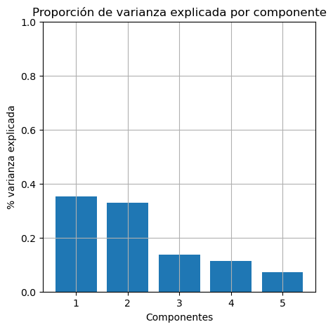

```python
pipeline.summary_reduccion()
```

#### Procedemos a realizar algoritmo de clasificacion (Arbol de decision)...

```python
pipeline.clasification(DecisionTreeClassifier, criterion='entropy', min_samples_split=50, random_state=42)
# - DecisionTreeClassifier: Clasificador de árbol de decisión
# - criterion='entropy': Criterio de división del árbol (entropía).La entropía se utiliza para medir la impureza de un conjunto de datos en el contexto de un árbol de decisión
# - min_samples_split=50: Número mínimo de muestras para dividir un nodo interno
# - random_state=42: Semilla para reproducibilidad en la generación de números aleatorios
pipeline.train_clasification()
```

Observamos la curva de ROC

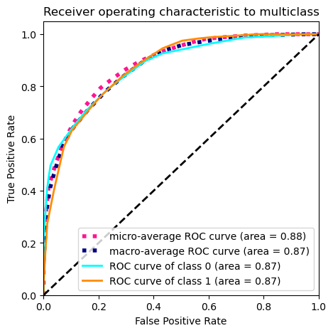

```python
pipeline.summary_training()
```

Una AUC-ROC de 0.87 indica que el modelo tiene una capacidad bastante buena para distinguir entre las dos clases, pero no es perfecto. Cuanto más cercano a 1.0 sea el valor, mejor es el rendimiento del modelo en términos de discriminación entre las clases. Sugiere que es un buen modelo de clasificacion en entrenamiento.

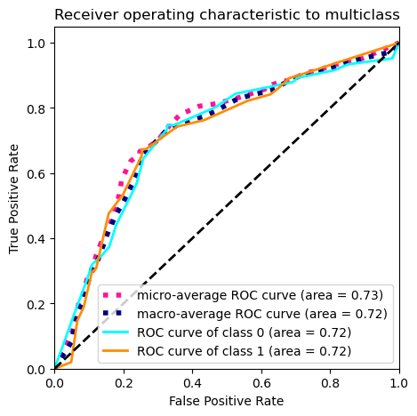

```python
pipeline.summary_test()
```

En test en cambio obtenemos un AUC-ROC más bajo con 0.73.

## Repetimos lo mismo cambiando el algoritmo de clasificación

Utilizamos ahora un random forest.

```python
pipeline.clasification(RandomForestClassifier, criterion='entropy', min_samples_split=50, random_state=42, n_estimators=1000)
# - RandomForestClassifier: Clasificador Random Forest
# - criterion='entropy': Criterio de división del árbol (entropía)
# - min_samples_split=50: Número mínimo de muestras para dividir un nodo interno
# - random_state=42: Semilla para reproducibilidad en la generación de números aleatorios
# - n_estimators=1000: Número de árboles en el bosque
pipeline.train_clasification()
```

Observamos la curva de ROC

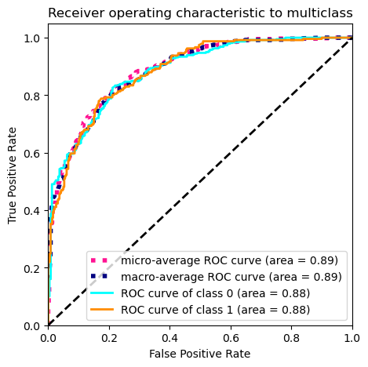

```python
pipeline.summary_training()
```

Una AUC-ROC de 0.89 indica que el modelo tiene una capacidad bastante buena para distinguir entre las dos clases, pero no es perfecto. Cuanto más cercano a 1.0 sea el valor, mejor es el rendimiento del modelo en términos de discriminación entre las clases. Sugiere que es un buen modelo de clasificacion en entrenamiento.

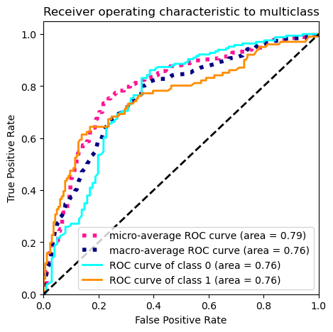

```python
pipeline.summary_test()
```

En test en cambio obtenemos un AUC-ROC más bajo con 0.79.

Pese a ello podemos validar que el segundo algoritmo mejora minimamente los resultados.